# Comparative Genomics Southern Flounder

```r
knitr::opts_chunk$set(warning = FALSE, message = FALSE)

source("lib/libraries.R")
source("lib/ggplot.R")
```

# Family B Female Map

## Load data

Required inputfiles are `genfile`: `*.raw` generated using `convert.pl` to convert filtered `*.tsv`-output from haplotyper and `mapfile`: `*.map` text file with two columns (first column is putative linkage group, second column is markername). Need to create mapfile based on markers in genfile before analysis.

```r
summary(FamB_F)
```

```
    Backcross

    No. individuals:    157

    No. phenotypes:     1
    Percent phenotyped: 100

    No. chromosomes:    13
        Autosomes:      1 2 3 4 5 6 7 8 9 10 11 12 13

    Total markers:      1944
    No. markers:        150 150 150 150 150 150 150 150 150 150 150 150 144
    Percent genotyped:  96.5
    Genotypes (%):      AA:50.1  AB:49.9
```

Raw data set contains 157 individuals and 1944 loci.

## Pre-mapping quality control

### Filter 1: Missing data

Missing genotypes (loci/individuals)

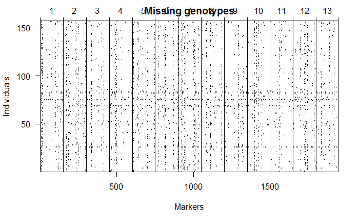

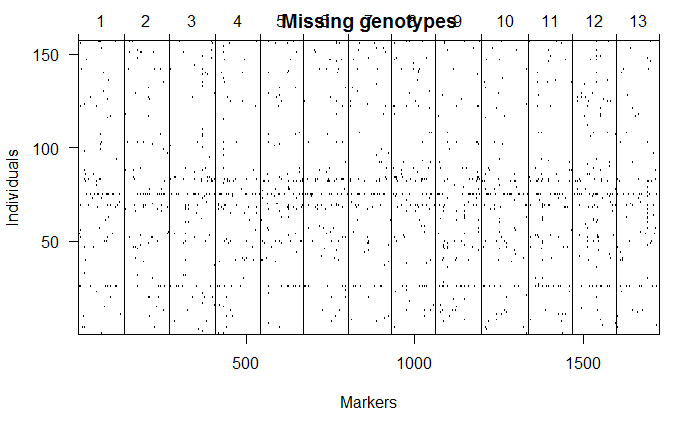

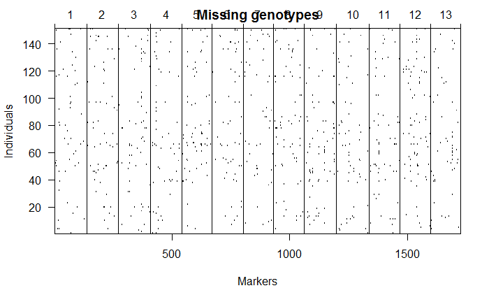

After filtering data set contains 151 individuals and 1727 loci.

### Filter 2: Omit duplicate individuals

Compare genotypes of pairs of individuals to identify pairs with unusually similar genotypes

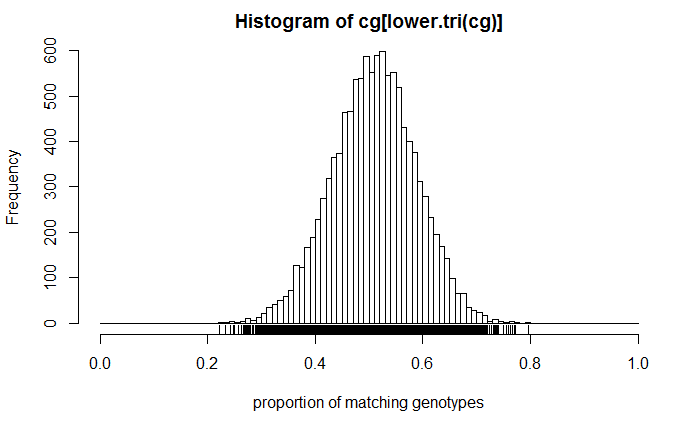

No matching individuals were identified.

```r
FamB_F.f2 <- FamB_F.f1
```

[output not shown]

Data set contains 151 individuals and 1727 loci.

### Filter 3: Omit duplicate markers

Identify matching markers. Drop duplicate markers but create table of corresponding marker to be mapped so the can be added post-mapping.

After filtering 1481 loci are retained.

### Filter 4: Drop loci with distorted segregation patterns

Loci should have specific segregation patterns based on marker type.

After filtering 1475 loci are retained.

### Filter 5: Genotype frequencies by individual

Determine genotype frequencies by individual and remove individuals as necessary.

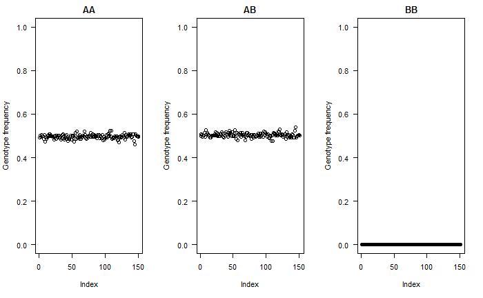

After filtering 151 individuals are retained.

## Determine correct linkage phase

Estimate recombination fraction (rf) & LOD score for each marker pair. Potentially switched markers are pairs of marker with strong association (LOD score) but rf >> 1/4.

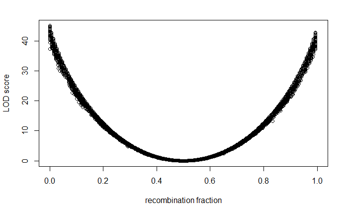

Form initial linkage groups and re-organize loci into initial LGs.

```r
init.lg <- formLinkageGroups(FamB_F.LP, max.rf = 0.35, min.lod = 6)
table(init.lg[,2])
```

```
 1  2  3  4  5  6  7  8  9 10 11 12 13 14 15 16 17 18 19 20 21 22 23 24 25 26 27 28 29 30 31 32 33 34 35 36 37
41 40 39 38 36 36 36 35 35 34 34 34 34 34 34 32 32 32 32 32 32 31 31 31 31 31 31 30 30 30 30 30 29 29 29 29 28
38 39 40 41 42 43 44 45 46 47 48 49 50 51 52
28 27 27 25 25 24 23 23 21 21 14  2  1  1  1
```

```r
# re-organize markers into inferred initial LGs
FamB_F.LP <- formLinkageGroups(FamB_F.LP, max.rf = 0.35, min.lod = 6, reorgMarkers=TRUE)
```

Plot rf vs LOD to identify chromosomes to switch alleles for.

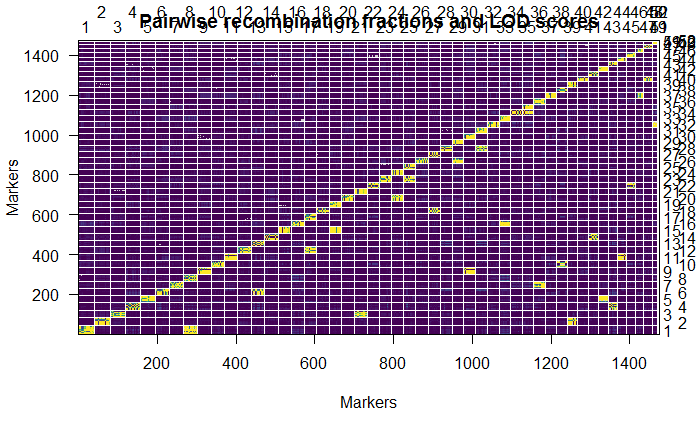

Switch alleles, re-estimate rf, form new linkage groups and re-organize markers.

```r
# use plot to identify chromosomes to switch alleles for
for (chr in c(8, 13, 17, 19, 21, 24:25, 27, 29:31,
              33, 35:39, 41:48)){
  toswitch <- markernames(FamB_F.LP, chr=(chr))
  FamB_F.LP <- switchAlleles(FamB_F.LP, toswitch)
}

# re-estimate rf
FamB_F.LP <- est.rf(FamB_F.LP)

# form new linkage groups & re-organize markers
init.lg <- formLinkageGroups(FamB_F.LP, max.rf=0.35, min.lod=6)
table(init.lg[,2])
FamB_F.LP <- formLinkageGroups(FamB_F.LP, max.rf=0.35, min.lod=6, reorgMarkers=TRUE)
```

Plot rf vs LOD:

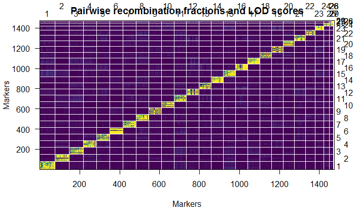

Switch alleles, re-estimate rf, form new linkage groups and re-organize markers.

```r
init.lg <- formLinkageGroups(FamB_F.LP, max.rf=0.35, min.lod=6)
table(init.lg[,2])
```

```
 1  2  3  4  5  6  7  8  9 10 11 12 13 14 15 16 17 18 19 20 21 22 23 24 25 26 27 28
76 71 70 67 66 66 65 65 63 63 62 62 62 61 61 61 60 59 58 57 54 49 48 44  2  1  1  1
```

Plot rf vs LOD:

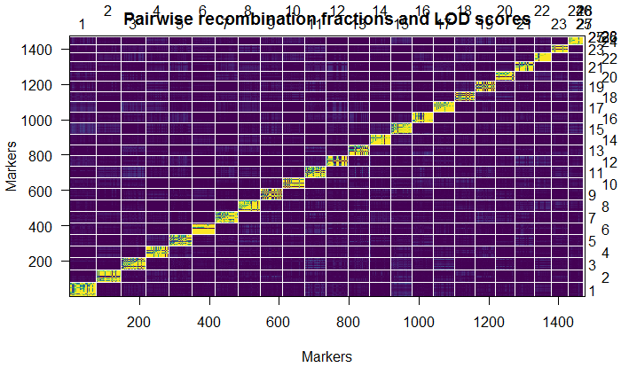

Drop marker in LG25-:

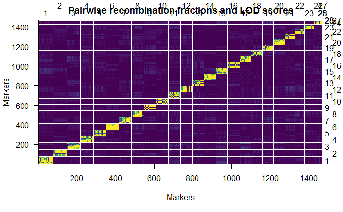

## Establish initial marker order

Establish initial marker order within LGs using greedy algorithm. Adds one marker at a time with previously added marker locations fixed. Position determined by minimizing number of obligate cross overs.

```r
FamB_F.final <- orderMarkers(FamB_F.final, chr=1:24)
```

[output not shown]

## Initial quality assessment

### Examine pairwise linkage & Identify gaps between markers

Plot rf vs LOD after ordering markers:

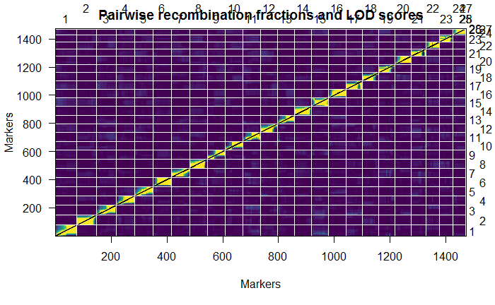

Large gaps between markers indicate that adjacent markers are only weakly linked. Compare average and largest spacing per LG.

```r
summaryMap(FamB_F.final)
```

```
        n.mar length ave.spacing max.spacing
1          76   58.4         0.8         5.4
2          71   77.5         1.1         8.6
3          70  111.5         1.6        31.6
4          67   86.6         1.3         8.6
5          66  176.6         2.7        64.3
6          66   90.4         1.4        14.4
7          65  825.4        12.9       771.2
8          65  135.0         2.1        50.5
9          63   76.1         1.2        10.0
10         63   66.5         1.1         8.7
11         62  123.6         2.0        21.0
12         62   74.5         1.2        17.0
13         62   86.2         1.4        11.9
14         61  112.8         1.9        50.8
15         61  109.5         1.8        19.1
16         61   63.8         1.1         9.5
17         60  104.2         1.8        17.0
18         59   72.2         1.2         7.1
19         58  121.4         2.1        26.3
20         57   73.2         1.3        15.4
21         54  108.6         2.0        17.3
22         49  109.0         2.3        25.3
23         48  123.8         2.6        33.6
24         44   84.0         2.0        10.3
25          2   10.0        10.0        10.0
27          1    0.0          NA          NA
28          1    0.0          NA          NA
overall  1474 3080.9         2.1       771.2
```

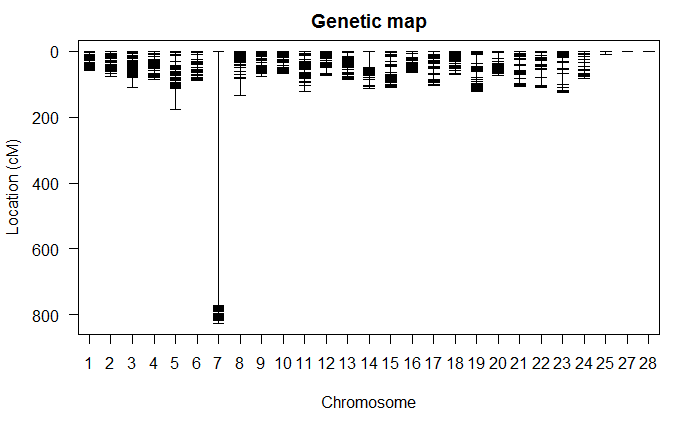

Drop markers one by one to determine change in chromosome length & change in log likelihood. Identify markers that result in smaller estimated chromosome length and increased LOD. Dropping terminal markers will usually result in decreased length.

```r
# drop each marker and compare effect
dropone <- droponemarker(FamB_F.final, maxit = 4000, tol = 1e-6,
                         error.prob = 0.001, verbose = TRUE) %>%
  add_rownames("Marker") %>%
  gather("Effect", "Change", 4:5)

# plot results
plot_dropone <- function(dropone){
  p <- ggplot(dropone, aes(x = pos, y = Change)) +
    geom_line() +
    geom_point(shape = 21, size = 2,
               color = "black", fill = "white") +
    facet_grid(Effect ~ ., scales = "free") +
    labs(x = paste("LG", dropone$chr, "Position", sep =" "), y = "Change if marker dropped") +
    theme_facet
  print(p)
}

dropone %>%
  group_by(chr) %>%
  do(plot = plot_dropone(.)) %>%
  ungroup()
```

Compare effect in terms of change in length and likelihood and identify top 10 loci with strongest effect per LG.

```r
# data frame with top10 markers with strongest effect
dropone_sum <- dropone %>%
  spread("Effect", "Change") %>%
  group_by(chr) %>%
  top_n(10, LOD) %>%
  ungroup() %>%
  arrange(chr, LOD)
```

Drop markers as necessary and re-estimate map.

```r
FamB_F.final <- drop.markers(FamB_F.final, "dDocent_Contig_169912") # LG24
FamB_F.final <- drop.markers(FamB_F.final, "dDocent_Contig_138502") # LG23
FamB_F.final <- drop.markers(FamB_F.final, "dDocent_Contig_156439") # LG22
FamB_F.final <- drop.markers(FamB_F.final, "dDocent_Contig_48243") # LG21
FamB_F.final <- drop.markers(FamB_F.final, "dDocent_Contig_344840") # LG21
FamB_F.final <- drop.markers(FamB_F.final, "dDocent_Contig_277952") # LG20
FamB_F.final <- drop.markers(FamB_F.final, "dDocent_Contig_36576") # LG19
FamB_F.final <- drop.markers(FamB_F.final, "dDocent_Contig_46435") # LG17
FamB_F.final <- drop.markers(FamB_F.final, "dDocent_Contig_141878") # LG15
FamB_F.final <- drop.markers(FamB_F.final, "dDocent_Contig_82981") # LG15
FamB_F.final <- drop.markers(FamB_F.final, "dDocent_Contig_11655") # LG14
FamB_F.final <- drop.markers(FamB_F.final, "dDocent_Contig_41004") # LG13
FamB_F.final <- drop.markers(FamB_F.final, "dDocent_Contig_123865") # LG12
FamB_F.final <- drop.markers(FamB_F.final, "dDocent_Contig_331600") # LG11
FamB_F.final <- drop.markers(FamB_F.final, "dDocent_Contig_11361") # LG10
FamB_F.final <- drop.markers(FamB_F.final, "dDocent_Contig_102279") # LG7
FamB_F.final <- drop.markers(FamB_F.final, "dDocent_Contig_307315") # LG6
FamB_F.final <- drop.markers(FamB_F.final, "dDocent_Contig_49942") # LG5
FamB_F.final <- drop.markers(FamB_F.final, "dDocent_Contig_2088") # LG4
FamB_F.final <- drop.markers(FamB_F.final, "dDocent_Contig_233139") # LG3
FamB_F.final <- drop.markers(FamB_F.final, "dDocent_Contig_166471") # LG25
FamB_F.final <- drop.markers(FamB_F.final, "dDocent_Contig_99420") # LG25
FamB_F.final <- drop.markers(FamB_F.final, "dDocent_Contig_18025") # LG26
```

```
Markers not found: dDocent_Contig_18025
```

```r
FamB_F.final <- drop.markers(FamB_F.final, "dDocent_Contig_285352") # LG27
FamB_F.final <- drop.markers(FamB_F.final, "dDocent_Contig_305002") # LG28
# re-estimate map after eliminating markers
FamB_F.dropl <- est.map(FamB_F.final, error.prob=0.001)
FamB_F.final <- replace.map(FamB_F.final, FamB_F.dropl)
# plot maps of all chromosomes
summaryMap(FamB_F.final)
```

```
        n.mar length ave.spacing max.spacing
1          76   49.0         0.7         5.4
2          71   55.8         0.8         8.2
3          69   69.6         1.0         7.8
4          66   65.6         1.0         8.5
5          65   79.5         1.2        16.5
6          65   68.3         1.1        14.4
7          64   52.8         0.8         9.5
8          65  120.8         1.9        50.8
9          63   64.0         1.0         9.7
10         62   58.3         1.0         8.7
11         61   82.6         1.4        11.9
12         61   57.5         1.0        16.1
13         61   68.7         1.1        11.9
14         60   59.0         1.0        18.2
15         59   88.9         1.5        17.4
16         61   53.1         0.9         9.5
17         59   87.1         1.5        16.0
18         59   62.6         1.1         7.1
19         57  107.9         1.9        25.7
20         56   62.3         1.1        15.4
21         52   97.4         1.9        17.3
22         48   53.2         1.1         8.7
23         47   96.0         2.1        28.8
24         43   74.9         1.8        13.5
overall  1450 1734.8         1.2        50.8
```

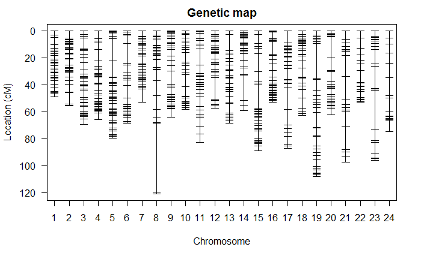

### Identify individuals with high number of XO

Observed number of crossovers per individual:

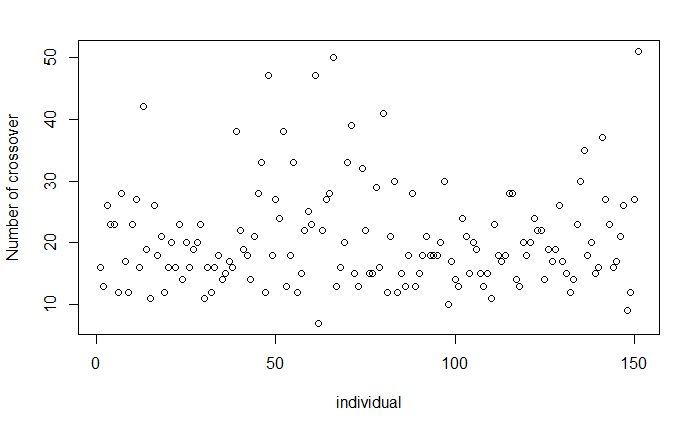

### Estimate genotyping error rate

Estimate genotyping error rate.

```r
# Estimate genotyping error rate
loglik <- err <- c(0.0001, 0.0005, 0.001, 0.0025, 0.005, 0.0075, 0.01, 0.015, 0.02)
for(i in seq(along=err)) {
  cat(i, "of", length(err), "\n")
  tempmap <- est.map(FamB_F.final, error.prob=err[i])
  loglik[i] <- sum(sapply(tempmap, attr, "loglik"))
}
```

```
1 of 9
2 of 9
3 of 9
4 of 9
5 of 9
6 of 9
7 of 9
8 of 9
9 of 9
```

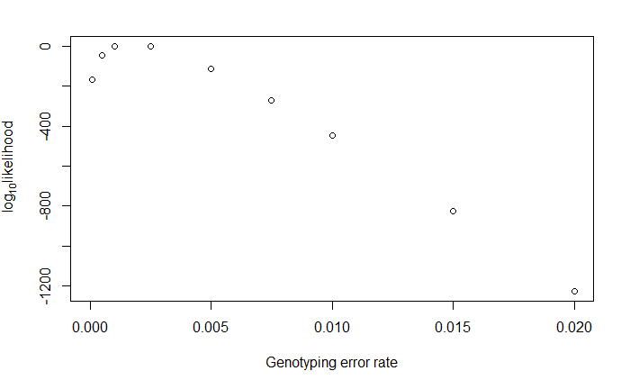

```r
lod <- (loglik - max(loglik))/log(10)
# plot log10 likelihood
par(mfrow=c(1,1), ps=12, cex=1)
plot(err, lod, xlab="Genotyping error rate", xlim=c(0,0.02), ylab=expression(paste(log[10], "likelihood")))
```

Genotyping error rate with highest likelihood is 0.001.

### Identify genotyping errors and code as missing

Tight double-crossovers (single marker out of phase with adjacent markers) indicate genotyping errors. Identify double cross-overs by calculating genotyping error LOD scores (Lincoln & Lander 1992). Calculate errorload (genotype being in error vs not being in error). Plot grid of LOD scores indicating genotypes likely to be in error: darker pixels likely to be error: white (LOD <2), grey (2 < LOD < 3), pink (3 < LOD < 4.5), purple (LOD >4.5)

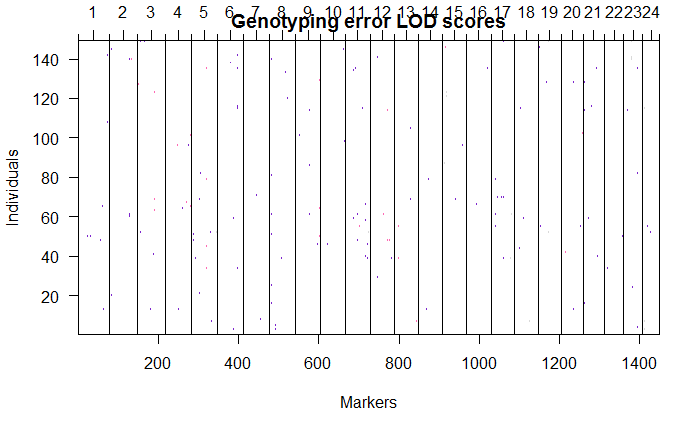

Eliminate genotypes (coded as missing) for LOD > 6 and re-estimate map.

268 genotypes were coded as missing.

## Re-order markers by LG and compare alternate orders

### Compare number obligate XO, LOD & Chromosome length to determine best order

Re-order markers after loci and individuals have been removed and use sliding window to compare alternate orders in terms of number of obligate cross overs and likelihood.

```r
# compare number of obligate crossovers for alternate orders
FamB_F.XO <- lapply(c(1:24), function(chr) {
  rip <- ripple(FamB_F.final, chr = chr, window = 7, method="countxo", error.prob = 0.001, maxit = 2000, tol = 1e-6)
  rip <- rip[1:11,]
})

# access each element in list using [[]]
# Ch1_XO <- as.data.frame(FamB_F.XO[[1]]) %>%
#  rename(Chr1 = obligXO) %>%
#  select(Chr1)

FamB_F.lik <- lapply(c(1:24), function(chr) {
  rip.lik <- ripple(FamB_F.final, chr = chr, window = 5, method="likelihood", error.prob=0.002, maxit=2000, tol=1e-4)
  rip.lik <- rip.lik[1:11,]
})
```

### Switch marker order as necessary

Identify order with lowest number of XO and highest LOD while minimizing chromosome length.

```r
FamB_F.lik[[24]]
```

```
Initial 1 2 3 4 5 6 7 8 9 10 11 12 13 14 15 16 17 18 19 20 21 22 23 24 25 26 27 28 29
1       1 2 3 4 5 6 7 8 9 10 11 12 13 14 15 16 17 18 19 20 21 22 23 24 25 26 27 28 29
2       1 2 3 4 5 6 7 8 9 10 11 12 13 14 15 16 17 18 19 20 21 22 23 24 25 26 27 28 29
3       1 2 3 4 5 6 7 8 9 10 11 12 13 14 15 16 17 18 19 20 21 22 23 24 25 26 27 28 29
4       1 2 3 4 5 6 7 8 9 10 11 12 13 14 15 16 17 18 19 20 21 22 23 24 25 26 27 28 29
5       1 2 3 4 5 6 7 8 9 10 11 12 13 14 15 16 17 18 19 20 21 22 23 24 25 26 27 28 29
6       1 2 3 4 5 6 7 8 9 10 11 12 13 14 15 16 17 18 19 20 21 22 23 24 25 26 27 28 29
7       1 2 3 4 5 6 7 8 9 10 11 12 13 14 15 16 17 18 19 20 21 22 23 24 25 26 27 28 29
8       1 2 3 4 5 6 7 8 9 10 11 12 13 14 15 16 17 18 19 20 21 22 23 24 25 26 27 28 29
9       1 2 3 4 5 6 7 8 9 10 11 12 13 14 15 16 17 18 19 20 21 22 23 24 25 26 27 28 29
10      1 2 3 4 5 6 7 8 9 10 11 12 13 14 15 16 17 18 19 20 21 22 23 24 25 26 27 28 29
                                                           LOD   chrlen
Initial 30 31 32 33 34 35 36 37 38 39 40 41 42 43 0.000000e+00 69.97884
1       30 31 32 33 34 35 36 37 38 39 42 40 41 43 1.894399e-06 69.97885
2       30 31 32 33 34 35 36 37 38 39 42 41 40 43 1.894399e-06 69.97885
3       30 31 32 33 34 35 36 37 38 42 39 40 41 43 1.894399e-06 69.97885
4       30 31 32 33 34 35 36 37 38 42 39 41 40 43 1.894399e-06 69.97885
5       30 31 32 33 34 35 36 37 39 38 42 40 41 43 1.894399e-06 69.97885
6       30 31 32 33 34 35 36 37 39 38 42 41 40 43 1.894399e-06 69.97885
7       30 31 32 33 34 35 36 37 42 38 39 40 41 43 1.894399e-06 69.97885
8       30 31 32 33 34 35 36 37 42 38 39 41 40 43 1.894399e-06 69.97885
9       30 31 32 33 34 35 36 37 39 42 38 40 41 43 1.894399e-06 69.97885
10      30 31 32 33 34 35 36 37 39 42 38 41 40 43 1.894399e-06 69.97885
```

## Post-odering quality assessment II

### Examine pairwise linkage & Identify gaps between markers

Plot rf vs LOD

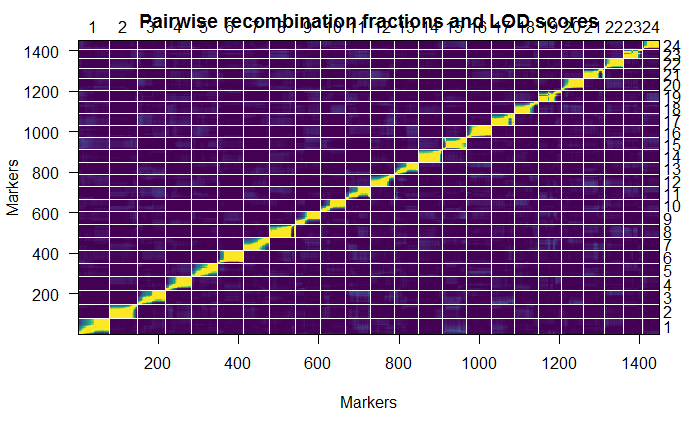

Identify large gaps between markers which is indicative of adjacent markers being only weakly linked.

```r
summaryMap(FamB_F.final)
```

```
        n.mar length ave.spacing max.spacing
1          76   49.0         0.7         4.9
2          71   55.1         0.8         8.3
3          69   68.7         1.0         7.9
4          66   64.5         1.0         8.6
5          65   77.7         1.2        16.8
6          65   69.3         1.1        14.7
7          64   53.4         0.8         9.6
8          65  122.2         1.9        51.8
9          63   62.3         1.0         9.0
10         62   58.2         1.0         8.8
11         61   82.1         1.4        11.3
12         61   57.0         1.0        16.4
13         61   68.2         1.1        12.1
14         60   59.0         1.0        17.5
15         59   86.9         1.5        16.7
16         61   53.9         0.9         9.6
17         59   84.6         1.5        16.3
18         59   62.1         1.1         7.2
19         57  108.9         1.9        26.2
20         56   62.7         1.1        15.7
21         52   95.3         1.9        16.6
22         48   53.2         1.1         8.8
23         47   94.3         2.1        29.3
24         43   72.9         1.7        12.8
overall  1450 1721.6         1.2        51.8
```

Plot maps of all linkage groups:

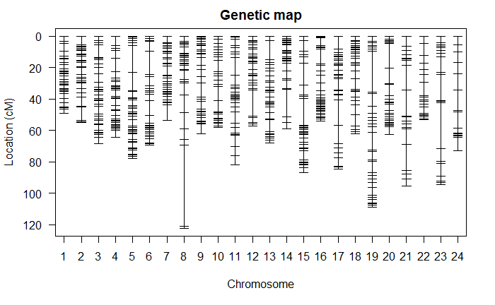

Drop markers one by one determine change in chromosome length & change in log likelihood. Identify markers that result in smaller estimated chromosome length and increased LOD.

```r
# drop each marker and compare effect
dropone <- droponemarker(FamB_F.final, maxit = 4000, tol = 1e-6,
                         error.prob = 0.001, verbose = TRUE) %>%
  add_rownames("Marker") %>%
  gather("Effect", "Change", 4:5)

# plot results
plot_dropone <- function(dropone){
  p <- ggplot(dropone, aes(x = pos, y = Change)) +
    geom_line() +
    geom_point(shape = 21, size = 2,
               color = "black", fill = "white") +
    facet_grid(Effect ~ ., scales = "free") +
    labs(x = paste("LG", dropone$chr, "Position", sep =" "), y = "Change if marker dropped") +
    theme_facet
  print(p)
}

dropone %>%
  group_by(chr) %>%
  do(plot = plot_dropone(.)) %>%
  ungroup()
```

Compare effect in terms of change in length and likelihood and identify top 10 loci with strongest effect per LG.

```r
# data frame with top10 markers with strongest effect
dropone_sum <- dropone %>%
  spread("Effect", "Change") %>%
  group_by(chr) %>%
  top_n(10, LOD) %>%
  ungroup() %>%
  arrange(chr, LOD)
```

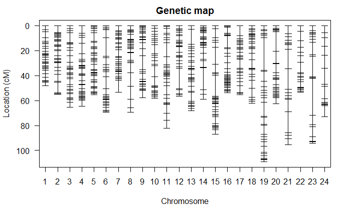

### Identify individuals with high number of XO

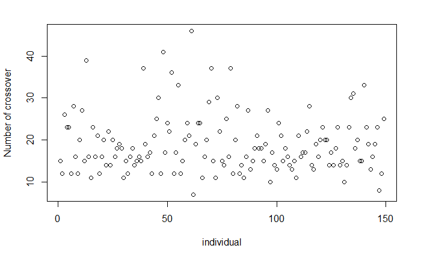

## Finalize map

Write files of finalized maps. Write files of finalized map. Map contains 1681 loci grouped into 24 LG.

# Family B Male Map

## Load data

Required inputfiles are `genfile`: `*.raw` generated using `convert.pl` to convert filtered `*.tsv`-output from haplotyper and `mapfile`: `*.map` text file with two columns (first column is putative linkage group, second column is markername). Need to create mapfile based on markers in genfile before analysis.

```r
Sum_FamB_M.raw
```

```
    Backcross

    No. individuals:    157

    No. phenotypes:     1
    Percent phenotyped: 100

    No. chromosomes:    13
        Autosomes:      1 2 3 4 5 6 7 8 9 10 11 12 13

    Total markers:      1914
    No. markers:        150 150 150 150 150 150 150 150 150 150 150 150 114
    Percent genotyped:  96.6
    Genotypes (%):      AA:49.9  AB:50.1
```

Raw data set contains 157 individuals and 1914 loci.

## Pre-mapping quality control

### Filter 1: Missing data

Missing genotypes (loci/individuals)

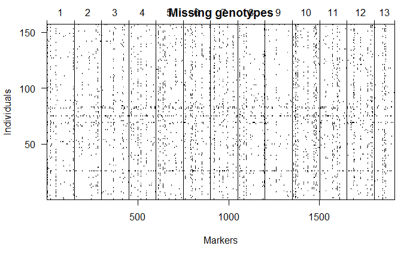

Omit loci with > 20% missing data and individuals with > 25% missing data.

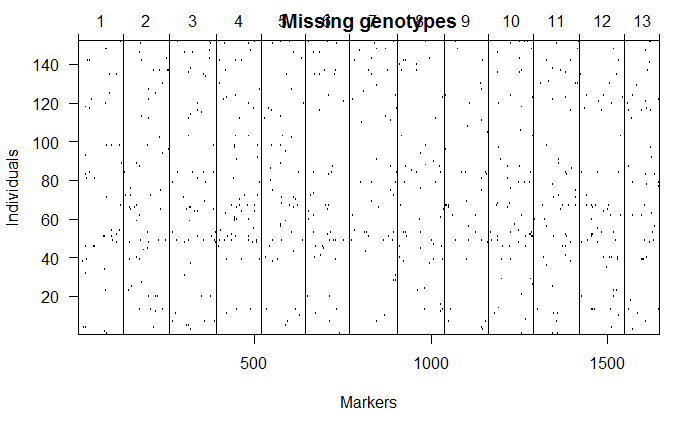

After filtering data set contains 152 individuals and 1648 loci.

### Filter 2: Omit duplicate individuals

Compare genotypes of pairs of individuals to identify pairs with unusually similar genotypes

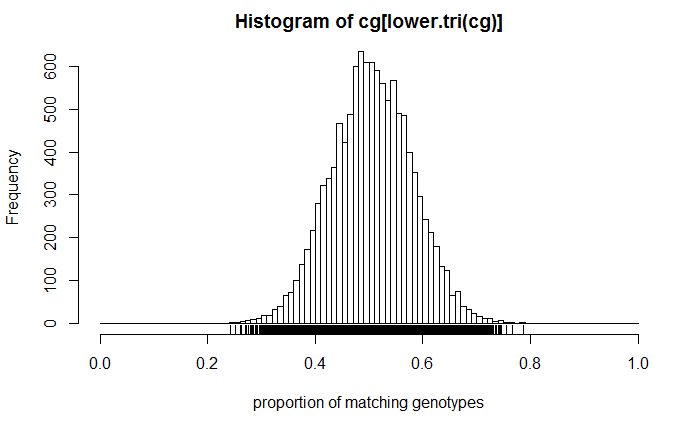

No matching individuals were identified.

Data set contains 152 individuals and 1648 loci.

### Filter 3: Omit duplicate markers

Identify matching markers. Drop duplicate markers but create table of corresponding marker to be mapped so the can be added post-mapping.

After filtering 1442 loci are retained.

### Filter 4: Drop loci with distroted segregation patterns

Loci should have specific segregation patterns based on marker type.

After filtering 1439 loci are retained.

### Filter 5: Genotype frequencies by individual

Determine genotype frequencies by individual and remove individuals as necessary.

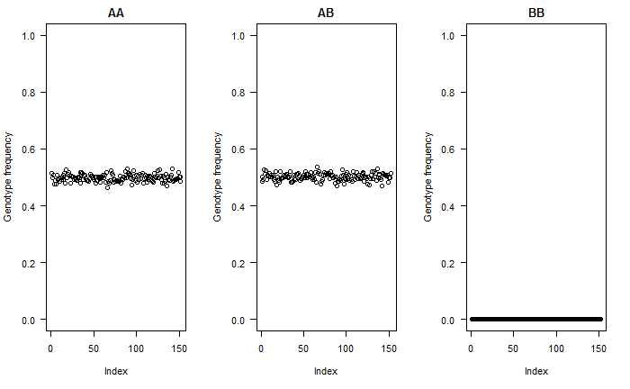

After filtering 152 individuals are retained.

## Determine correct linkage phase

Estimate recombination fraction (rf) & LOD score for each marker pair. Potentially switched markers are pairs of marker with strong association (LOD score) but rf >> 1/4.

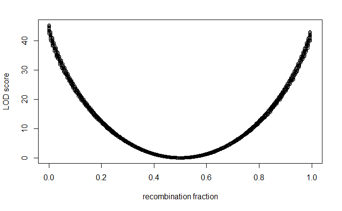

Form initial linkage groups and re-organize loci into initial LGs.

```r
# form initial linkage groups
init.lg <- formLinkageGroups(FamB_M.LP, max.rf = 0.35, min.lod = 6)
table(init.lg[,2])
```

```
 1  2  3  4  5  6  7  8  9 10 11 12 13 14 15 16 17 18 19 20 21 22 23 24 25 26 27 28
50 40 40 40 39 38 37 36 36 34 34 34 33 32 32 32 32 32 31 31 30 30 30 30 29 29 29 28
29 30 31 32 33 34 35 36 37 38 39 40 41 42 43 44 45 46 47 48 49 50
28 28 28 28 28 27 26 26 26 25 25 24 24 23 23 21 20 20 20 19  1  1
```

```r
# re-organize markers into inferred initial LGs
FamB_M.LP <- formLinkageGroups(FamB_M.LP, max.rf = 0.35, min.lod = 6, reorgMarkers=TRUE)
```

Plot rf vs LOD to identify chromosomes to switch alleles for.

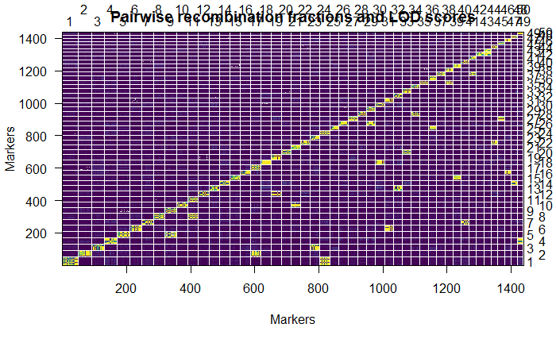

Switch alleles, re-estimate rf, form new linkage groups and re-organize markers.

```r
init.lg <- formLinkageGroups(FamB_M.LP, max.rf=0.35, min.lod=6)
table(init.lg[,2])
```

```
 1  2  3  4  5  6  7  8  9 10 11 12 13 14 15 16 17 18 19 20 21 22 23 24 25 26
80 75 72 70 70 66 65 64 61 61 60 59 59 57 55 52 52 51 51 50 49 46 29 29 28 26
```

```r
FamB_M.LP <- formLinkageGroups(FamB_M.LP, max.rf=0.35, min.lod=6, reorgMarkers=TRUE)
```

Plot rf vs LOD after switching alleles:

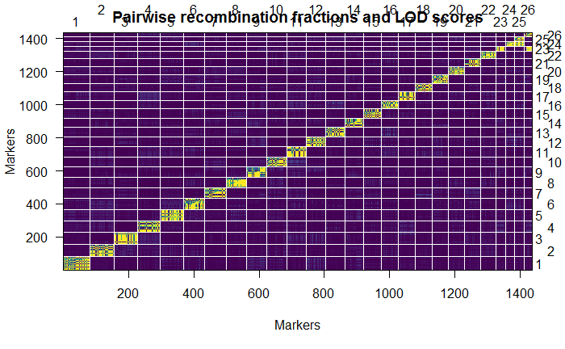

Switch alleles, re-estimate rf, form new linkage groups and re-organize markers.

```r
init.lg <- formLinkageGroups(FamB_M.LP, max.rf=0.35, min.lod=6)
table(init.lg[,2])
```

```
 1  2  3  4  5  6  7  8  9 10 11 12 13 14 15 16 17 18 19 20 21 22 23 24
80 75 72 70 70 66 65 64 61 61 60 59 59 57 57 55 55 52 52 51 51 50 49 46
```

```r
FamB_M.LP <- formLinkageGroups(FamB_M.LP, max.rf=0.35, min.lod=6, reorgMarkers=TRUE)
```

Plot rf vs LOD after switching alleles:

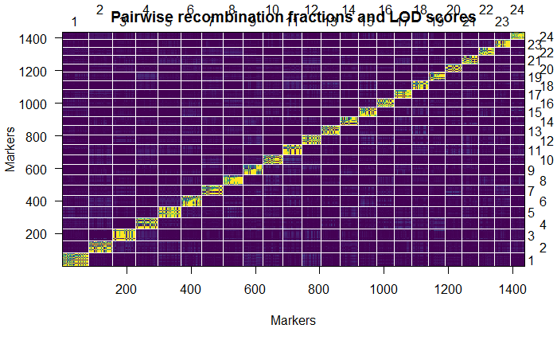

## Establish initial marker order

Establish initial marker order within LGs using greedy algorithm. Adds one marker at a time with previously added marker locations fixed. Position determined by minimizing number of obligate cross overs.

## Initial quality assessment

### Examine pairwise linkage & Identify gaps between markers

Plot rf vs LOD after ordering markers:

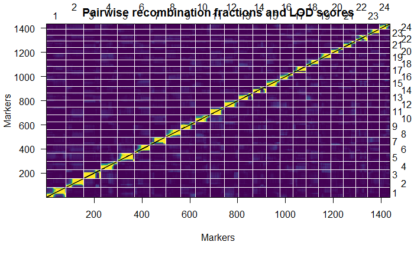

Large gaps between markers indicate that adjacent markers are only weakly linked. Compare average and largest spacing per LG.

```r
summaryMap(FamB_M.final)
```

```
        n.mar length ave.spacing max.spacing
1          80   93.5         1.2        16.2
2          75   65.8         0.9         6.3
3          72   98.5         1.4        19.0
4          70   60.0         0.9         7.8
5          70  154.2         2.2        74.9
6          66   89.4         1.4        11.8
7          65   99.1         1.5        17.9
8          64   75.4         1.2         8.4
9          61   81.0         1.3        11.0
10         61   74.4         1.2         7.6
11         60   85.2         1.4        15.1
12         59   61.9         1.1        11.0
13         59   93.8         1.6        17.1
14         57  138.1         2.5        38.7
15         57   64.0         1.1         9.4
16         55   71.2         1.3         7.7
17         55  114.5         2.1        28.5
18         52   83.1         1.6        13.4
19         52   69.8         1.4         7.8
20         51   59.5         1.2         8.6
21         51   65.8         1.3         8.5
22         50  109.4         2.2        20.8
23         49   63.4         1.3         7.8
24         46   70.3         1.6        10.2
overall  1437 2041.2         1.4        74.9
```

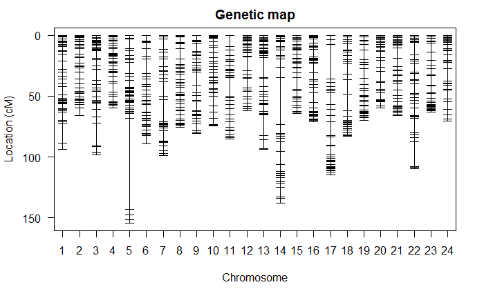

Drop markers one by one to determine change in chromosome length & change in log likelihood. Identify markers that result in smaller estimated chromosome length and increased LOD. Dropping terminal markers will usually result in decreased length.

```r
# drop each marker and compare effect
dropone <- droponemarker(FamB_M.final, maxit = 4000, tol = 1e-6,
                         error.prob = 0.001, verbose = TRUE) %>%
  add_rownames("Marker") %>%
  gather("Effect", "Change", 4:5)
```

[output not shown]

```
Deprecated, use tibble::rownames_to_column() instead.
```

Compare effect in terms of change in length and likelihood and identify top 10 loci with strongest effect per LG.

```r
# data frame with top10 markers with strongest effect
dropone_sum <- dropone %>%
  spread("Effect", "Change") %>%
  group_by(chr) %>%
  top_n(10, LOD) %>%
  ungroup() %>%
  arrange(chr, LOD)
```

Drop markers as necessary and re-estimate map.

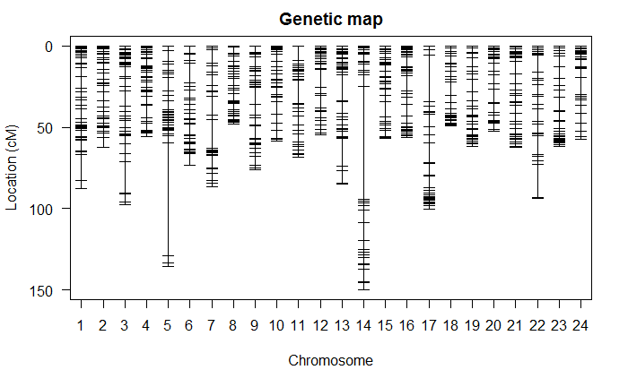